# Optimal Treatment Analysis

## Outcome Variable

**Outcome Variable:** whz

## Predictor Variables

**Intervention Variable:** impfloor

**Adjustment Set:**

- arm
- sex
- W_mage
- meducyrs
- feducyrs
- hhwealth_quart
- hfoodsec
- W_mhtcm
- W_nrooms
- W_nchldlt5
- W_parity
- impsan
- safeh20
- delta_W_mage
- delta_meducyrs
- delta_feducyrs
- delta_hhwealth_quart
- delta_hfoodsec
- delta_W_mhtcm
- delta_W_nrooms
- delta_W_nchldlt5
- delta_W_parity
- delta_impsan
- delta_safeh20

## Stratifying Variables

The analysis was stratified on these variable(s):

- agecat
- studyid
- country

## Data Summary

| agecat | studyid | country | impfloor | n_cell | n |
| --- | --- | --- | --- | --- | --- |
| Birth | ki0047075b-MAL-ED | BANGLADESH | 1 | 205 | 222 |
| Birth | ki0047075b-MAL-ED | BANGLADESH | 0 | 17 | 222 |
| Birth | ki0047075b-MAL-ED | BRAZIL | 1 | 165 | 167 |
| Birth | ki0047075b-MAL-ED | BRAZIL | 0 | 2 | 167 |
| Birth | ki0047075b-MAL-ED | INDIA | 1 | 178 | 188 |
| Birth | ki0047075b-MAL-ED | INDIA | 0 | 10 | 188 |
| Birth | ki0047075b-MAL-ED | NEPAL | 1 | 64 | 159 |
| Birth | ki0047075b-MAL-ED | NEPAL | 0 | 95 | 159 |
| Birth | ki0047075b-MAL-ED | PERU | 1 | 54 | 252 |
| Birth | ki0047075b-MAL-ED | PERU | 0 | 198 | 252 |
| Birth | ki0047075b-MAL-ED | SOUTH AFRICA | 1 | 196 | 216 |
| Birth | ki0047075b-MAL-ED | SOUTH AFRICA | 0 | 20 | 216 |
| Birth | ki0047075b-MAL-ED | TANZANIA, UNITED REPUBLIC OF | 1 | 7 | 113 |
| Birth | ki0047075b-MAL-ED | TANZANIA, UNITED REPUBLIC OF | 0 | 106 | 113 |
| Birth | ki1000108-CMC-V-BCS-2002 | INDIA | 1 | 71 | 71 |
| Birth | ki1000108-CMC-V-BCS-2002 | INDIA | 0 | 0 | 71 |
| Birth | ki1000108-IRC | INDIA | 1 | 253 | 253 |
| Birth | ki1000108-IRC | INDIA | 0 | 0 | 253 |
| Birth | ki1017093-NIH-Birth | BANGLADESH | 1 | 24 | 28 |
| Birth | ki1017093-NIH-Birth | BANGLADESH | 0 | 4 | 28 |
| Birth | ki1017093c-NIH-Crypto | BANGLADESH | 1 | 18 | 23 |
| Birth | ki1017093c-NIH-Crypto | BANGLADESH | 0 | 5 | 23 |
| Birth | ki1114097-CONTENT | PERU | 1 | 2 | 2 |
| Birth | ki1114097-CONTENT | PERU | 0 | 0 | 2 |
| Birth | kiGH5241-JiVitA-3 | BANGLADESH | 1 | 455 | 7659 |
| Birth | kiGH5241-JiVitA-3 | BANGLADESH | 0 | 7204 | 7659 |
| Birth | kiGH5241-JiVitA-4 | BANGLADESH | 1 | 15 | 185 |
| Birth | kiGH5241-JiVitA-4 | BANGLADESH | 0 | 170 | 185 |
| 6 months | ki0047075b-MAL-ED | BANGLADESH | 1 | 221 | 240 |
| 6 months | ki0047075b-MAL-ED | BANGLADESH | 0 | 19 | 240 |

[output cut: 62 more lines]

The following strata were considered:

- agecat: 24 months, studyid: ki0047075b-MAL-ED, country: BANGLADESH
- agecat: 24 months, studyid: ki0047075b-MAL-ED, country: BRAZIL
- agecat: 24 months, studyid: ki0047075b-MAL-ED, country: INDIA
- agecat: 24 months, studyid: ki0047075b-MAL-ED, country: NEPAL
- agecat: 24 months, studyid: ki0047075b-MAL-ED, country: PERU
- agecat: 24 months, studyid: ki0047075b-MAL-ED, country: SOUTH AFRICA
- agecat: 24 months, studyid: ki0047075b-MAL-ED, country: TANZANIA, UNITED REPUBLIC OF
- agecat: 24 months, studyid: ki1000108-CMC-V-BCS-2002, country: INDIA
- agecat: 24 months, studyid: ki1000108-IRC, country: INDIA
- agecat: 24 months, studyid: ki1017093-NIH-Birth, country: BANGLADESH
- agecat: 24 months, studyid: ki1017093b-PROVIDE, country: BANGLADESH
- agecat: 24 months, studyid: ki1017093c-NIH-Crypto, country: BANGLADESH
- agecat: 24 months, studyid: ki1113344-GMS-Nepal, country: NEPAL
- agecat: 24 months, studyid: ki1114097-CONTENT, country: PERU
- agecat: 24 months, studyid: kiGH5241-JiVitA-3, country: BANGLADESH
- agecat: 24 months, studyid: kiGH5241-JiVitA-4, country: BANGLADESH
- agecat: 6 months, studyid: ki0047075b-MAL-ED, country: BANGLADESH
- agecat: 6 months, studyid: ki0047075b-MAL-ED, country: BRAZIL
- agecat: 6 months, studyid: ki0047075b-MAL-ED, country: INDIA
- agecat: 6 months, studyid: ki0047075b-MAL-ED, country: NEPAL
- agecat: 6 months, studyid: ki0047075b-MAL-ED, country: PERU
- agecat: 6 months, studyid: ki0047075b-MAL-ED, country: SOUTH AFRICA
- agecat: 6 months, studyid: ki0047075b-MAL-ED, country: TANZANIA, UNITED REPUBLIC OF
- agecat: 6 months, studyid: ki1000108-CMC-V-BCS-2002, country: INDIA
- agecat: 6 months, studyid: ki1000108-IRC, country: INDIA
- agecat: 6 months, studyid: ki1017093-NIH-Birth, country: BANGLADESH
- agecat: 6 months, studyid: ki1017093b-PROVIDE, country: BANGLADESH
- agecat: 6 months, studyid: ki1017093c-NIH-Crypto, country: BANGLADESH
- agecat: 6 months, studyid: ki1113344-GMS-Nepal, country: NEPAL
- agecat: 6 months, studyid: ki1114097-CONTENT, country: PERU
- agecat: 6 months, studyid: kiGH5241-JiVitA-3, country: BANGLADESH
- agecat: 6 months, studyid: kiGH5241-JiVitA-4, country: BANGLADESH
- agecat: Birth, studyid: ki0047075b-MAL-ED, country: BANGLADESH
- agecat: Birth, studyid: ki0047075b-MAL-ED, country: BRAZIL
- agecat: Birth, studyid: ki0047075b-MAL-ED, country: INDIA
- agecat: Birth, studyid: ki0047075b-MAL-ED, country: NEPAL
- agecat: Birth, studyid: ki0047075b-MAL-ED, country: PERU
- agecat: Birth, studyid: ki0047075b-MAL-ED, country: SOUTH AFRICA
- agecat: Birth, studyid: ki0047075b-MAL-ED, country: TANZANIA, UNITED REPUBLIC OF
- agecat: Birth, studyid: ki1000108-CMC-V-BCS-2002, country: INDIA
- agecat: Birth, studyid: ki1000108-IRC, country: INDIA
- agecat: Birth, studyid: ki1017093-NIH-Birth, country: BANGLADESH
- agecat: Birth, studyid: ki1017093c-NIH-Crypto, country: BANGLADESH
- agecat: Birth, studyid: ki1114097-CONTENT, country: PERU
- agecat: Birth, studyid: kiGH5241-JiVitA-3, country: BANGLADESH
- agecat: Birth, studyid: kiGH5241-JiVitA-4, country: BANGLADESH

### Dropped Strata

Some strata were dropped due to rare outcomes:

- agecat: Birth, studyid: ki0047075b-MAL-ED, country: BRAZIL
- agecat: Birth, studyid: ki1000108-CMC-V-BCS-2002, country: INDIA
- agecat: Birth, studyid: ki1000108-IRC, country: INDIA
- agecat: Birth, studyid: ki1017093-NIH-Birth, country: BANGLADESH
- agecat: Birth, studyid: ki1114097-CONTENT, country: PERU
- agecat: 6 months, studyid: ki0047075b-MAL-ED, country: BRAZIL
- agecat: 6 months, studyid: ki1000108-CMC-V-BCS-2002, country: INDIA
- agecat: 6 months, studyid: ki1000108-IRC, country: INDIA
- agecat: 24 months, studyid: ki0047075b-MAL-ED, country: BRAZIL
- agecat: 24 months, studyid: ki1000108-CMC-V-BCS-2002, country: INDIA
- agecat: 24 months, studyid: ki1000108-IRC, country: INDIA

## Methods Detail

We’re interested in the causal parameters $E[Y_a]$ for all values of $a \in \mathcal{A}$. These parameters represent the mean outcome if, possibly contrary to fact, we intervened to set all units to have $A=a$. Under the randomization and positivity assumptions, these are identified by the statistical parameters $\psi_a=E_W[E_{Y|A,W}(Y|A=a,W)]$. In addition, we’re interested in the mean of $Y$, $E[Y]$ under no intervention (the observed mean). We will estimate these parameters by using SuperLearner to fit the relevant likelihood factors – $E_{Y|A,W}(Y|A=a,W)$ and $p(A=a|W)$, and then updating our likelihood fit using a joint TMLE.

For unadjusted analyses ($W=\{\}$), initial likelihoods were estimated using Lrnr_glm to estimate the simple $E(Y|A)$ and Lrnr_mean to estimate $p(A)$. For adjusted analyses, a small library containing Lrnr_glmnet, Lrnr_xgboost, and Lrnr_mean was used.

Having estimated these parameters, we will then use the delta method to estimate relative risks and attributable risks relative to a prespecified baseline level of $A$.

# Results Detail

## Results Plots

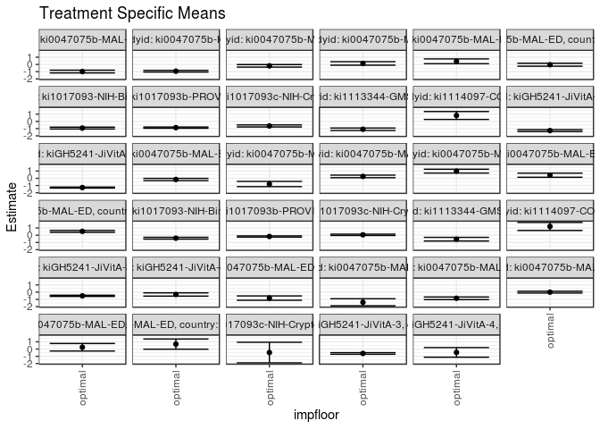

## Results Table

### Parameter: TSM

| agecat | studyid | country | intervention_level | baseline_level | estimate | ci_lower | ci_upper |
| --- | --- | --- | --- | --- | --- | --- | --- |
| Birth | ki0047075b-MAL-ED | BANGLADESH | optimal | observed | -0.8216146 | -1.1199544 | -0.5232749 |
| Birth | ki0047075b-MAL-ED | INDIA | optimal | observed | -1.3964575 | -1.8849276 | -0.9079874 |
| Birth | ki0047075b-MAL-ED | NEPAL | optimal | observed | -0.8506328 | -1.0285043 | -0.6727612 |
| Birth | ki0047075b-MAL-ED | PERU | optimal | observed | -0.0034303 | -0.1293312 | 0.1224705 |
| Birth | ki0047075b-MAL-ED | SOUTH AFRICA | optimal | observed | 0.2486343 | -0.2733469 | 0.7706156 |
| Birth | ki0047075b-MAL-ED | TANZANIA, UNITED REPUBLIC OF | optimal | observed | 0.6870249 | -0.0149869 | 1.3890367 |
| Birth | ki1017093c-NIH-Crypto | BANGLADESH | optimal | observed | -0.4820715 | -1.9045020 | 0.9403590 |
| Birth | kiGH5241-JiVitA-3 | BANGLADESH | optimal | observed | -0.6041170 | -0.7159295 | -0.4923044 |
| Birth | kiGH5241-JiVitA-4 | BANGLADESH | optimal | observed | -0.4607900 | -1.1253665 | 0.2037865 |
| 6 months | ki0047075b-MAL-ED | BANGLADESH | optimal | observed | -0.1654077 | -0.3219718 | -0.0088437 |
| 6 months | ki0047075b-MAL-ED | INDIA | optimal | observed | -0.7930320 | -1.1563161 | -0.4297478 |
| 6 months | ki0047075b-MAL-ED | NEPAL | optimal | observed | 0.2573495 | 0.0784141 | 0.4362849 |
| 6 months | ki0047075b-MAL-ED | PERU | optimal | observed | 0.9861208 | 0.7199199 | 1.2523217 |
| 6 months | ki0047075b-MAL-ED | SOUTH AFRICA | optimal | observed | 0.4269185 | 0.1420824 | 0.7117546 |
| 6 months | ki0047075b-MAL-ED | TANZANIA, UNITED REPUBLIC OF | optimal | observed | 0.5337085 | 0.4003663 | 0.6670507 |
| 6 months | ki1017093-NIH-Birth | BANGLADESH | optimal | observed | -0.4117111 | -0.5369779 | -0.2864442 |
| 6 months | ki1017093b-PROVIDE | BANGLADESH | optimal | observed | -0.1749204 | -0.2631002 | -0.0867405 |
| 6 months | ki1017093c-NIH-Crypto | BANGLADESH | optimal | observed | 0.0554366 | -0.0359506 | 0.1468237 |
| 6 months | ki1113344-GMS-Nepal | NEPAL | optimal | observed | -0.5480715 | -0.8023192 | -0.2938239 |
| 6 months | ki1114097-CONTENT | PERU | optimal | observed | 1.2118951 | 0.6564424 | 1.7673477 |
| 6 months | kiGH5241-JiVitA-3 | BANGLADESH | optimal | observed | -0.5121189 | -0.5957046 | -0.4285333 |
| 6 months | kiGH5241-JiVitA-4 | BANGLADESH | optimal | observed | -0.3244000 | -0.5514660 | -0.0973339 |
| 24 months | ki0047075b-MAL-ED | BANGLADESH | optimal | observed | -0.9839346 | -1.1732525 | -0.7946168 |
| 24 months | ki0047075b-MAL-ED | INDIA | optimal | observed | -0.9349152 | -1.0550985 | -0.8147318 |
| 24 months | ki0047075b-MAL-ED | NEPAL | optimal | observed | -0.1940999 | -0.3672263 | -0.0209736 |
| 24 months | ki0047075b-MAL-ED | PERU | optimal | observed | 0.1384386 | -0.1025027 | 0.3793799 |
| 24 months | ki0047075b-MAL-ED | SOUTH AFRICA | optimal | observed | 0.4367833 | 0.1094621 | 0.7641045 |
| 24 months | ki0047075b-MAL-ED | TANZANIA, UNITED REPUBLIC OF | optimal | observed | -0.0377739 | -0.2441764 | 0.1686285 |
| 24 months | ki1017093-NIH-Birth | BANGLADESH | optimal | observed | -0.9266939 | -1.0534156 | -0.7999723 |
| 24 months | ki1017093b-PROVIDE | BANGLADESH | optimal | observed | -0.8690376 | -0.9550178 | -0.7830575 |
| 24 months | ki1017093c-NIH-Crypto | BANGLADESH | optimal | observed | -0.6326021 | -0.7764205 | -0.4887837 |
| 24 months | ki1113344-GMS-Nepal | NEPAL | optimal | observed | -1.0885531 | -1.2562270 | -0.9208792 |
| 24 months | ki1114097-CONTENT | PERU | optimal | observed | 0.8135163 | 0.2682450 | 1.3587876 |
| 24 months | kiGH5241-JiVitA-3 | BANGLADESH | optimal | observed | -1.2759678 | -1.4098881 | -1.1420475 |
| 24 months | kiGH5241-JiVitA-4 | BANGLADESH | optimal | observed | -1.2819204 | -1.3482666 | -1.2155743 |

### Parameter: E(Y)

| agecat | studyid | country | intervention_level | baseline_level | estimate | ci_lower | ci_upper |
| --- | --- | --- | --- | --- | --- | --- | --- |
| Birth | ki0047075b-MAL-ED | BANGLADESH | observed | observed | -0.9902252 | -1.1311070 | -0.8493435 |
| Birth | ki0047075b-MAL-ED | INDIA | observed | observed | -1.0536702 | -1.1965043 | -0.9108361 |
| Birth | ki0047075b-MAL-ED | NEPAL | observed | observed | -0.9364780 | -1.0810831 | -0.7918728 |
| Birth | ki0047075b-MAL-ED | PERU | observed | observed | -0.0384921 | -0.1542085 | 0.0772244 |
| Birth | ki0047075b-MAL-ED | SOUTH AFRICA | observed | observed | -0.0073148 | -0.1632037 | 0.1485740 |
| Birth | ki0047075b-MAL-ED | TANZANIA, UNITED REPUBLIC OF | observed | observed | 0.8080531 | 0.6030895 | 1.0130167 |
| Birth | ki1017093c-NIH-Crypto | BANGLADESH | observed | observed | -0.7508696 | -1.2358912 | -0.2658480 |
| Birth | kiGH5241-JiVitA-3 | BANGLADESH | observed | observed | -0.7650020 | -0.7919937 | -0.7380102 |
| Birth | kiGH5241-JiVitA-4 | BANGLADESH | observed | observed | -0.2903784 | -0.4497929 | -0.1309639 |
| 6 months | ki0047075b-MAL-ED | BANGLADESH | observed | observed | -0.1354618 | -0.2647919 | -0.0061317 |
| 6 months | ki0047075b-MAL-ED | INDIA | observed | observed | -0.7056667 | -0.8312524 | -0.5800810 |
| 6 months | ki0047075b-MAL-ED | NEPAL | observed | observed | 0.1286317 | -0.0051407 | 0.2624042 |
| 6 months | ki0047075b-MAL-ED | PERU | observed | observed | 1.0527407 | 0.9299728 | 1.1755087 |
| 6 months | ki0047075b-MAL-ED | SOUTH AFRICA | observed | observed | 0.5403280 | 0.3866002 | 0.6940558 |
| 6 months | ki0047075b-MAL-ED | TANZANIA, UNITED REPUBLIC OF | observed | observed | 0.5162517 | 0.3853881 | 0.6471153 |
| 6 months | ki1017093-NIH-Birth | BANGLADESH | observed | observed | -0.4362094 | -0.5254855 | -0.3469333 |
| 6 months | ki1017093b-PROVIDE | BANGLADESH | observed | observed | -0.2083706 | -0.2927992 | -0.1239419 |
| 6 months | ki1017093c-NIH-Crypto | BANGLADESH | observed | observed | 0.0297622 | -0.0491685 | 0.1086930 |
| 6 months | ki1113344-GMS-Nepal | NEPAL | observed | observed | -0.6267309 | -0.7246812 | -0.5287807 |
| 6 months | ki1114097-CONTENT | PERU | observed | observed | 1.0684318 | 0.9515274 | 1.1853362 |
| 6 months | kiGH5241-JiVitA-3 | BANGLADESH | observed | observed | -0.5889715 | -0.6165580 | -0.5613850 |
| 6 months | kiGH5241-JiVitA-4 | BANGLADESH | observed | observed | -0.3684250 | -0.4392750 | -0.2975751 |
| 24 months | ki0047075b-MAL-ED | BANGLADESH | observed | observed | -0.8208255 | -0.9429246 | -0.6987264 |
| 24 months | ki0047075b-MAL-ED | INDIA | observed | observed | -0.9522907 | -1.0676596 | -0.8369219 |
| 24 months | ki0047075b-MAL-ED | NEPAL | observed | observed | -0.3487330 | -0.4631704 | -0.2342957 |
| 24 months | ki0047075b-MAL-ED | PERU | observed | observed | 0.1199005 | -0.0000331 | 0.2398341 |
| 24 months | ki0047075b-MAL-ED | SOUTH AFRICA | observed | observed | 0.4267017 | 0.3074751 | 0.5459283 |
| 24 months | ki0047075b-MAL-ED | TANZANIA, UNITED REPUBLIC OF | observed | observed | 0.0429953 | -0.0825155 | 0.1685060 |
| 24 months | ki1017093-NIH-Birth | BANGLADESH | observed | observed | -0.9106710 | -1.0090143 | -0.8123277 |
| 24 months | ki1017093b-PROVIDE | BANGLADESH | observed | observed | -0.8879412 | -0.9708680 | -0.8050144 |
| 24 months | ki1017093c-NIH-Crypto | BANGLADESH | observed | observed | -0.6103502 | -0.7050157 | -0.5156847 |
| 24 months | ki1113344-GMS-Nepal | NEPAL | observed | observed | -1.1914974 | -1.2943015 | -1.0886933 |
| 24 months | ki1114097-CONTENT | PERU | observed | observed | 0.5668293 | 0.4302437 | 0.7034148 |
| 24 months | kiGH5241-JiVitA-3 | BANGLADESH | observed | observed | -1.2914115 | -1.3239489 | -1.2588741 |
| 24 months | kiGH5241-JiVitA-4 | BANGLADESH | observed | observed | -1.2302244 | -1.2892920 | -1.1711567 |

### Parameter: PAR

| agecat | studyid | country | intervention_level | baseline_level | estimate | ci_lower | ci_upper |
| --- | --- | --- | --- | --- | --- | --- | --- |
| Birth | ki0047075b-MAL-ED | BANGLADESH | optimal | observed | -0.1686106 | -0.4813820 | 0.1441609 |
| Birth | ki0047075b-MAL-ED | INDIA | optimal | observed | 0.3427873 | -0.1138677 | 0.7994422 |
| Birth | ki0047075b-MAL-ED | NEPAL | optimal | observed | -0.0858452 | -0.2076473 | 0.0359569 |
| Birth | ki0047075b-MAL-ED | PERU | optimal | observed | -0.0350617 | -0.1041091 | 0.0339857 |
| Birth | ki0047075b-MAL-ED | SOUTH AFRICA | optimal | observed | -0.2559491 | -0.7614505 | 0.2495522 |
| Birth | ki0047075b-MAL-ED | TANZANIA, UNITED REPUBLIC OF | optimal | observed | 0.1210282 | -0.5343407 | 0.7763971 |
| Birth | ki1017093c-NIH-Crypto | BANGLADESH | optimal | observed | -0.2687980 | -1.5009969 | 0.9634008 |
| Birth | kiGH5241-JiVitA-3 | BANGLADESH | optimal | observed | -0.1608850 | -0.2707979 | -0.0509721 |
| Birth | kiGH5241-JiVitA-4 | BANGLADESH | optimal | observed | 0.1704116 | -0.4481733 | 0.7889966 |
| 6 months | ki0047075b-MAL-ED | BANGLADESH | optimal | observed | 0.0299459 | -0.0611986 | 0.1210905 |
| 6 months | ki0047075b-MAL-ED | INDIA | optimal | observed | 0.0873653 | -0.2725193 | 0.4472498 |
| 6 months | ki0047075b-MAL-ED | NEPAL | optimal | observed | -0.1287178 | -0.2662076 | 0.0087720 |
| 6 months | ki0047075b-MAL-ED | PERU | optimal | observed | 0.0666199 | -0.1637037 | 0.2969436 |
| 6 months | ki0047075b-MAL-ED | SOUTH AFRICA | optimal | observed | 0.1134095 | -0.1608466 | 0.3876656 |
| 6 months | ki0047075b-MAL-ED | TANZANIA, UNITED REPUBLIC OF | optimal | observed | -0.0174568 | -0.0544143 | 0.0195007 |
| 6 months | ki1017093-NIH-Birth | BANGLADESH | optimal | observed | -0.0244984 | -0.1179239 | 0.0689272 |
| 6 months | ki1017093b-PROVIDE | BANGLADESH | optimal | observed | -0.0334502 | -0.0595867 | -0.0073136 |
| 6 months | ki1017093c-NIH-Crypto | BANGLADESH | optimal | observed | -0.0256743 | -0.0707027 | 0.0193541 |
| 6 months | ki1113344-GMS-Nepal | NEPAL | optimal | observed | -0.0786594 | -0.3075531 | 0.1502343 |
| 6 months | ki1114097-CONTENT | PERU | optimal | observed | -0.1434633 | -0.6765274 | 0.3896009 |
| 6 months | kiGH5241-JiVitA-3 | BANGLADESH | optimal | observed | -0.0768526 | -0.1562895 | 0.0025843 |
| 6 months | kiGH5241-JiVitA-4 | BANGLADESH | optimal | observed | -0.0440251 | -0.2674796 | 0.1794294 |
| 24 months | ki0047075b-MAL-ED | BANGLADESH | optimal | observed | 0.1631091 | 0.0169394 | 0.3092789 |
| 24 months | ki0047075b-MAL-ED | INDIA | optimal | observed | -0.0173756 | -0.0490195 | 0.0142683 |
| 24 months | ki0047075b-MAL-ED | NEPAL | optimal | observed | -0.1546331 | -0.2876425 | -0.0216238 |
| 24 months | ki0047075b-MAL-ED | PERU | optimal | observed | -0.0185381 | -0.2254878 | 0.1884116 |
| 24 months | ki0047075b-MAL-ED | SOUTH AFRICA | optimal | observed | -0.0100816 | -0.3256487 | 0.3054855 |
| 24 months | ki0047075b-MAL-ED | TANZANIA, UNITED REPUBLIC OF | optimal | observed | 0.0807692 | -0.0973311 | 0.2588695 |
| 24 months | ki1017093-NIH-Birth | BANGLADESH | optimal | observed | 0.0160229 | -0.0866026 | 0.1186484 |
| 24 months | ki1017093b-PROVIDE | BANGLADESH | optimal | observed | -0.0189036 | -0.0437156 | 0.0059085 |
| 24 months | ki1017093c-NIH-Crypto | BANGLADESH | optimal | observed | 0.0222519 | -0.0996125 | 0.1441164 |
| 24 months | ki1113344-GMS-Nepal | NEPAL | optimal | observed | -0.1029443 | -0.2540832 | 0.0481946 |
| 24 months | ki1114097-CONTENT | PERU | optimal | observed | -0.2466870 | -0.7806992 | 0.2873252 |
| 24 months | kiGH5241-JiVitA-3 | BANGLADESH | optimal | observed | -0.0154437 | -0.1440425 | 0.1131551 |
| 24 months | kiGH5241-JiVitA-4 | BANGLADESH | optimal | observed | 0.0516961 | 0.0125578 | 0.0908344 |